# Problem Set 9

Due date: 4 December

```r
library(tidyverse)
library(modelsummary)
library(marginaleffects)
library(poliscidata)
library(readr)
censusAggregate_1 <- read_csv("censusAggregate-1.csv")
View(censusAggregate_1)
```

**Total points: 40**

## Question 1

*Points: 10*

**Note**

10/10

Table 1 below reports the results from two regression models. In Model 1 in Table 1 $Y$ is regressed on $X_1$ and, in Model 2, $Y$ is regressed on both $X_1$ and $X_2$. Why might $X_1$ be statistically significant at conventional levels in Model 1 but statistically insignificant in Model 2? Be as specific as possible.

[figure not shown]

$X_1$ might be statistically significant at conventional levels in Model 1 but statistically insignificant in Model 2 as Model 2 introduces $X_2$, suggesting that $X_2$ accounts for the true relationship that appeared to exist between $X_1$ and Y, and that the relationship between $X_1$ and Y is spurious and driven by a lurking variable.

This is a case similar to the example shown in class that seemed to suggest a relationship between the proportion of smokers in a state and the share of the vote received by Mitt Romney in 2012. In that example, $X_1$ would be proportion of smokers in the state with Y being the share of the vote received by Mitt Romney. When only $X_1$ was in the regression model, the results were statistically significant at a p-value of 0.009, giving the appearance that states in which a greater proportion of the population smoked, Mitt Romney received a greater share of the vote than in states in which smaller proportions of the population smoked. However, when $X_2$, the conservative advantage variable, was introduced to the regression model, $X_1$ was statistically insignificant in the model with a p-value of 0.729, while $X_2$ was statistically significant, confirming that conservative advantage ($X_2$) was the variable producing the effect on Y rather than the proportion of citizens who smoked in a state ($X_1$).

Like the example shown in class, the relationship between $X_1$ and Y in Table 1 is likely spurious and driven by lurking variable, $X_2$, which accounts for the true effect observed on Y; ultimately, the introduction of $X_2$ in the model reveals this, causing $X_1$ to be statistically insignificant in Model 2, though it was statistically significant in Model 1.

## Question 2

*Points: 10*

**Note**

8/10

Using the `censusAggregate` dataset (posted on ELMs), which is survey data aggregated to the state level (1972-2000), estimate a regression with `vote` as the dependent variable and the following independent variables: `nonSouth`, `edr`, and `pcthsg`. Report the results in a professionally formatted table and interpret the regression results.

Also, create a figure to display the predicted values (with confidence intervals) for the effect of `pcthsg` on the turnout rate. Lastly, is it meaningful to interpret the constant term on its own? Why, or why not?

**Note**

`vote` is the turnout rate in a state in a given year (i.e., the number of people who voted divided by the number eligible to vote).

`nonSouth` is a dummy variable equal to `0` for Southern states and a `1` for non-Southern states.

`pcthsg` is the percentage of the population in a state that graduated high school.

`edr` is a dummy variable equal to `1` for states that used election-day registration and a `0` for states without election-day registration.

```r
votereg <- lm(vote ~ nonSouth + edr + pcthsg, data = censusAggregate_1)
summary(votereg)
```

```
Call:
lm(formula = vote ~ nonSouth + edr + pcthsg, data = censusAggregate_1)

Residuals:
     Min       1Q   Median       3Q      Max
-19.6259  -3.3554   0.0282   3.6670  15.9988

Coefficients:
            Estimate Std. Error t value Pr(>|t|)
(Intercept) 54.00180    2.61603  20.643  < 2e-16 ***
nonSouth     5.54555    0.79695   6.958 1.68e-11 ***
edr          5.79234    1.05645   5.483 7.99e-08 ***
pcthsg       0.10074    0.03615   2.787  0.00561 **
---
Signif. codes:  0 '***' 0.001 '**' 0.01 '*' 0.05 '.' 0.1 ' ' 1

Residual standard error: 5.652 on 353 degrees of freedom
Multiple R-squared:  0.2813,    Adjusted R-squared:  0.2752
F-statistic: 46.05 on 3 and 353 DF,  p-value: < 2.2e-16
```

```r
tidy(votereg)
```

```
# A tibble: 4 × 5
  term        estimate std.error statistic  p.value
  <chr>          <dbl>     <dbl>     <dbl>    <dbl>
1 (Intercept)   54.0      2.62       20.6  1.18e-62
2 nonSouth       5.55     0.797       6.96 1.68e-11
3 edr            5.79     1.06        5.48 7.99e- 8
4 pcthsg         0.101    0.0362      2.79 5.61e- 3
```

```r
modelsummary(votereg,
             coef_rename = c(nonSouth = "Non-Southern States",
                             edr = "Election Day Registration",
                             pcthsg = "High School Graduates (% State Population)"),
             statistic = c("t = {statistic}", "SE = {std.error}", "conf.int", "p.value"))
```

|  | (1) |
| --- | --- |
| (Intercept) | 54.002 |
|  | t = 20.643 |
|  | SE = 2.616 |
|  | [48.857, 59.147] |
|  | (<0.001) |
| Non-Southern States | 5.546 |
|  | t = 6.958 |
|  | SE = 0.797 |
|  | [3.978, 7.113] |
|  | (<0.001) |
| Election Day Registration | 5.792 |
|  | t = 5.483 |
|  | SE = 1.056 |
|  | [3.715, 7.870] |
|  | (<0.001) |
| High School Graduates (% State Population) | 0.101 |
|  | t = 2.787 |
|  | SE = 0.036 |
|  | [0.030, 0.172] |
|  | (0.006) |
| Num.Obs. | 357 |
| R2 | 0.281 |
| R2 Adj. | 0.275 |
| AIC | 2255.8 |
| BIC | 2275.2 |
| Log.Lik. | −1122.884 |
| F | 46.049 |
| RMSE | 5.62 |

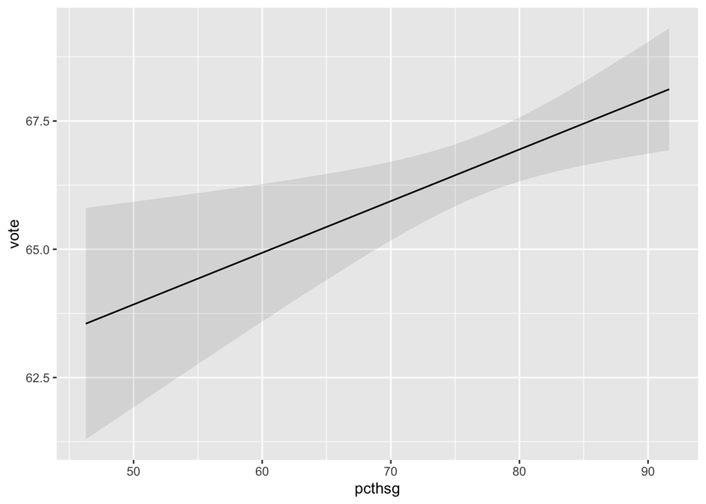

```r
plot_predictions(votereg, condition = "pcthsg", conf_level = 0.95)
```

**Note**

Provide more meaningful axis labels.

On average, non-Southern states were associated with a 5.546 point higher voter turnout rate than Southern states.

**Note**

… holding all else constant.

This is statistically significant with a p-value <0.001. The 95% confidence interval is [3.978, 7.113]. As the confidence interval does not include 0, this also provides support for the statistical significance of the findings.

Furthermore, states with election day registration available were associated with 5.792 point increase in voter turnout than states without election day registration, on average.

**Note**

… holding all else constant.

This is statistically significant with a p-value <0.001. The 95% confidence interval is [3.715, 7.870]. As the 95% confidence does not contain 0, that also supports the statistical significance of the findings.

A one percentage point increase in the percentage of the population in a state that graduated high school was associated with a 0.101 point increase in voter turnout, on average.

**Note**

… holding all else constant.

This is statistically significant at a p-value of 0.006. Furthermore, the confidence interval, [0.030, 0.172], does not contain 0, supporting the statistical significance of the findings.

The constant term is not meaningful on its own. Though nonSouth and edr could be set to 0 (as they are both binary dummy variables), it is not possible for pcthsg to be set to 0 as there is no way that 0% of a state’s population could have graduated from high school (there would be at least some high school graduates). Specifically, in the dataset, the lowest recorded percentage of high school graduates in a state is 46.29%.

## Question 3

*Points: 5*

**Note**

2/5

Using the regression results from the previous question, evaluate the null hypothesis that the effects (i.e., regression coefficients) of `nonSouth` and `pcthsg` are jointly equal to zero. Can you reject the null hypothesis? Be sure to demonstrate how you reached a definitive conclusion.

**Note**

You need to test whether `nonSouth` and `pcthsg` are jointly ineffectual, not that all variables are.

Using the regression results from the previous question, the F-test is a useful way to evaluate the null hypothesis that the effects of nonSouth, edr, and pcthsg are jointly equal to 0. The F-statistic is 46.05, and the p-value is < 2.2e-16. As the p-value associated with the F-statistic is (significantly) less than 0.05, this suggests that it is (highly) unlikely that the coefficients are jointly equal to 0. Thus, we can reject the null hypothesis.

## Question 4

*Points: 15*

**Note**

12/15

Using one of the other data sets available in the `poliscidata` package pick one dependent variable and two or more independent variables. Run a regression of the dependent variable on the independent variables. In your answer, describe why you picked the variables you did, produce a professionally formatted results table, and describe your statistical and substantive findings.

```r
z <- lm(effectiveness ~ free_corrupt + dem_score14, data = world)
summary(z)
```

```
Call:
lm(formula = effectiveness ~ free_corrupt + dem_score14, data = world)

Residuals:
     Min       1Q   Median       3Q      Max
-18.4897  -4.8598   0.2904   5.9353  15.2991

Coefficients:
             Estimate Std. Error t value Pr(>|t|)
(Intercept)   1.61827    1.69235   0.956   0.3405
free_corrupt  0.98853    0.04253  23.241   <2e-16 ***
dem_score14   0.81243    0.41978   1.935   0.0549 .
---
Signif. codes:  0 '***' 0.001 '**' 0.01 '*' 0.05 '.' 0.1 ' ' 1

Residual standard error: 7.329 on 147 degrees of freedom
  (17 observations deleted due to missingness)
Multiple R-squared:  0.9037,    Adjusted R-squared:  0.9024
F-statistic: 689.7 on 2 and 147 DF,  p-value: < 2.2e-16
```

```r
tidy(z, conf.int = T)
```

```
# A tibble: 3 × 7
  term         estimate std.error statistic  p.value conf.low conf.high
  <chr>           <dbl>     <dbl>     <dbl>    <dbl>    <dbl>     <dbl>
1 (Intercept)     1.62     1.69       0.956 3.41e- 1  -1.73        4.96
2 free_corrupt    0.989    0.0425    23.2   4.41e-51   0.904       1.07
3 dem_score14     0.812    0.420      1.94  5.49e- 2  -0.0171      1.64
```

```r
modelsummary(z,
             coef_rename = c(free_corrupt = "Freedom from Corruption",
                             dem_score14 = "Democracy Score"),
             statistic = c("t = {statistic}", "SE = {std.error}", "conf.int", "p.value"))
```

|  | (1) |
| --- | --- |
| (Intercept) | 1.618 |
|  | t = 0.956 |
|  | SE = 1.692 |
|  | [−1.726, 4.963] |
|  | (0.341) |
| Freedom from Corruption | 0.989 |
|  | t = 23.241 |
|  | SE = 0.043 |
|  | [0.904, 1.073] |
|  | (<0.001) |
| Democracy Score | 0.812 |
|  | t = 1.935 |
|  | SE = 0.420 |
|  | [−0.017, 1.642] |
|  | (0.055) |
| Num.Obs. | 150 |
| R2 | 0.904 |
| R2 Adj. | 0.902 |
| AIC | 1028.2 |
| BIC | 1040.2 |
| Log.Lik. | −510.097 |
| F | 689.700 |
| RMSE | 7.26 |

For the dependent variable I used the variable “effectiveness” (in the world dataset) which describes a country’s score on Kaufmann’s 100-point government effectiveness scale. For the two independent variables, I chose “free_corrupt” and “dem_score14”. The variable, free_corrupt, is based on the Heritage Foundation’s corruption rating (on a 100-point scale). The variable, dem_score14, is based on the Economist’s 10-point democracy scoring system, with higher scores representing more democratic governments.

I decided to pick the variable, effectiveness, as I was curious what domestic political factors influence government effectiveness. Furthermore, as I am interested in international development, I was interested to see if corruption was associated with increased or decreased government effectiveness (on average) as some argue that corruption “sands the wheels” (decreases effectiveness) while others counter that it “greases the wheels” or increases government effectiveness. Lastly, I chose to look at a country’s democracy score as I was interested in seeing if democracies or more authoritarian regimes had higher government effectiveness scores (on average) as democracies are often argued to have more effective governments.

A one unit increase in freedom from corruption was associated with a 0.98853 increase in government effectiveness.

**Note**

… holding all else constant.

This is statistically significant at a p-value <2e-16. Furthermore, the 95% confidence interval [0.904, 1.073] does not contain 0, supporting the statistical significance of the results. The substantive findings of the regression output suggest that countries can potentially increase their government effectiveness (by around 1 point) by decreasing corruption (by one point). Though the change seems small, a small change in overall government effectiveness can have substantial and positive effects on a country and its government (bureaucracy). A one unit increase in democracy score is associated with a 0.81243 increase in government effectiveness score, on average. This is not statistically significant as the p-value, 0.0549, is greater than 0.05. Furthermore, the 95% confidence interval [-0.0171, 1.64] contains 0. As such, it is not possible to reject the null for the Democracy Score coefficient as it is possible it could equal 0.

Based on the findings of the data, a country with limited resources seeking to improve overall government effectiveness (as defined by Kaufmann’s scoring) in the present or shorter-term should invest in and prioritize reducing corruption within the government versus democratization (however, that is not to say that democratization should be totally discounted as a potentially longer-term goal).

Ultimately, the intercept is not interpretable or meaningful on its own as neither the free_corrupt or dem_score14 can take on values of 0.